# General Philosophy

Week 3: Induction

Jonny McIntosh

# INTRODUCTION

**CASE 1**

I have an apple tree. Every year, for the past forty years, the apples that it has produced have been green.

I ask you, what colour will the apples that it produces this year be?

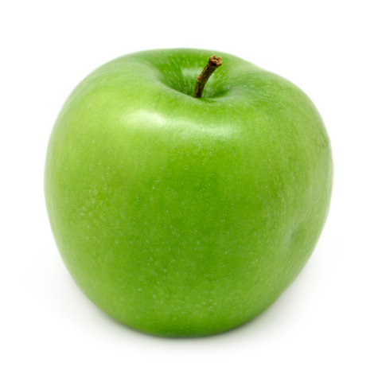

You infer that the apples will (probably) be green.

This sort of inference is known as an **INDUCTIVE** inference.

This week:

- What is induction?
- Hume's problem
- A pragmatic solution
- A reliablist solution

# WHAT IS INDUCTION?

Induction plays a crucial role in our cognitive economies.

1. Jonny's previous lectures have been incredibly informative and entertaining
2. So Jonny's lecture today will (probably) be incredibly informative and entertaining too
1. The sun has risen every day for millions of years
2. So the sun will (probably) rise tomorrow as well

But what exactly is induction? How does it differ from other forms of inference?

# DEDUCTIVE INFERENCES

On the one hand, induction contrasts with the following sort of inference:

**CASE 2**

There has been a murder. You have managed to narrow down the list of suspects to the maid and the butler. You have excellent reason to think that the maid has an alibi, and you know that if the maid has an alibi, she didn't do it.

[figure not shown]

You infer that the butler did it.

This is an instance of **DEDUCTION**: the conclusion, taken together with the premises from which it is drawn, constitutes a deductively valid argument.

Equivalently: the conclusion is **DEDUCTIVELY ENTAILED** by the premises.

1. Either the maid did it or the butler did it
2. The maid has an alibi
3. If the maid has an alibi, the maid didn't do it
4. So the butler did it.

(This is an example of an argument whose deductive validity is **FORMAL**: there are no interpretations in which the premises are true and the conclusion is false.

Other deductively valid arguments are **INFORMALLY** valid: there are no possibilities in which the premises are all true and the conclusion is false.)

The conclusion of an inductive inference, by contrast, is **NOT** deductively entailed by the premises from which it is drawn.

Even if the apples have been green every year for the past forty, it **MAY** be that this year they won't be.

# OTHER INFERENCES

On the other hand, induction also contrasts with the following sort of inference:

**CASE 3**

I have an apple tree. Every year, for the past forty years, the apples that it has produced have been green.

I ask you, what colour will the apples that it produces this year be?

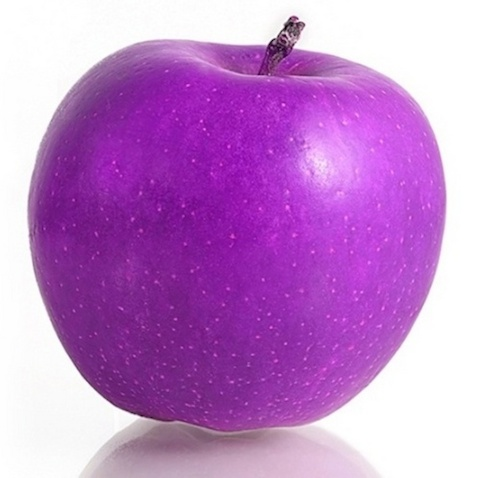

You infer that the apples will (probably) be purple.

In a genuine case of induction, the conclusion is **SUPPORTED** by the premises. In **CASE 3**, this doesn't hold.

Putting these two contrasts together:

Induction is the practice of inferring a conclusion from premises which, though they don't deductively entail the conclusion, nevertheless support it.

# ABDUCTION

Induction is characterised in a broad way here to include so-called **INFERENCE TO THE BEST EXPLANATION** or **ABDUCTION** - inferences such as:

1. The streets are wet
2. So it has (probably) been raining

Some philosophers distinguish between abduction and a narrow notion of **INDUCTION PROPER**, exemplified in **CASE 1**. It is not easy to say what the distinction here is, and some philosophers (Gilbert Harman) argue that there isn't one. For our purposes, we can ignore these issues.

**INFERENCES** and **ARGUMENTS**:

- Inferences are **ACTS**: drawings of conclusions from sets of premises.
- Arguments are (abstract) **OBJECTS** used in inferences.

# HUME'S PROBLEM

Hume asks, what is the **BASIS** or **FOUNDATION** of induction?

His surprising answer: it's **NOT** based on reason.

# HUME'S ARGUMENT

"I shall allow, if you please, that the one proposition may be justly inferred from the other: I know in fact, that it always is inferred. But if you insist that the inference is made by a chain of reasoning, I desire you to produce that reasoning."

Hume, *Enquiry concerning Human Understanding*, §4, Par. 16.

Isn't Hume's demand easily met?

1. Every year, for the past forty years, the apples this tree has produced have been green
2. So the apples it will produce this year will (probably) be green too

But we suppose that this inference differs from:

1. Every year, for the past forty years, the apples this tree has produced have been green
2. So the apples it will produce this year will (probably) be purple?

We suppose that, in the first case, but not the second, the premise supports the conclusion.

Hume asks: on what basis do we draw such distinctions? What is the foundation of this difference in our attitude?

Hume thinks that the supposition that the premises of our inductive inferences support their conclusions is ultimately founded on the assumption that nature is **UNIFORM**, that the future will resemble the past.

But what is the basis of this **PRINCIPLE OF THE UNIFORMITY OF NATURE**?

Not **DEDUCTION**. For there's no contradiction in supposing that it is false.

Not **INDUCTION**. For that would be to reason in a circle:

"[A]ll our experimental conclusions proceed on the supposition that the future will be conformable to the past. To endeavour, therefore, the proof of this last supposition by probable arguments, or arguments concerning existence, must be evidently going in a circle, and taking that for granted which is the very point in question."

Hume, *Enquiry concerning Human Understanding*, §4, Par. 19.

# HUME'S SCEPTICISM

Hume despairs of finding any rational basis for induction.

This is clearly, in some sense, **INDUCTIVE SCEPTICISM**:

We cannot know that induction has a rational basis. (Because it doesn't!)

Is Hume also sceptic about induction in a more radical sense? Does he think that we cannot know or be justified in believing the conclusions of our inductive inferences?

- That the apples on my tree will (probably) be green?
- That the sun will (probably) rise tomorrow?
- There's a wealth of evidence that Hume looks on inductive science very favourably.
- But if induction has no rational basis, how can it be any different from reading tea leaves?

**OPTION 1**

In asking about the "basis" or "foundation" of induction, Hume only intends to raise a question about the psychological origin of our inductive practice.

**OPTION 2**

Think back to week 1 on Hume and his scepticism with regard to the senses:

"here is the chief and most confounding objection to excessive scepticism, that no durable good can ever result from it; while it remains in its full force and vigour. We need only ask such a sceptic, *What his meaning is? And what he proposes by all these curious researches?*"

Hume, *Enquiry concerning Human Understanding*, §12, P23.

There is surely a difference here between induction and reading tea leaves!

If the sceptic convinces us that reading tea leaves has no basis in reason, we can easily give it up and continue our lives.

But even if the sceptic convinces us that **INDUCTION** has no basis in reason, she can't hope for the same effect. We cannot give up induction, and even if we could, our lives would be very impoverished.

Don't try crossing the road without performing any inductive inference!

# A PRAGMATIC SOLUTION

"We do not perform ... an inductive inference with the pretension of obtaining a true statement. What we obtain is a wager; and it is the best wager we can lay"

Hans Reichenbach *Experience and Prediction*, p. 356-7.

First pass:

1. Either nature is uniform or it isn't
2. If nature is uniform, induction is reliable
3. If nature is not uniform, no non-deductive method of inference is reliable
4. So induction is reliable if any non-deductive method of inference is!

But why accept the third premise here? If nature is not uniform, why couldn't some non-deductive method of inference, method X, be reliable?

If method X were reliable, we could discover that it was reliable...

**BY INDUCTION**!

Method X has been reliable in the past, so method X is reliable generally.

So more precisely:

1. Either nature is uniform or it isn't
2. If nature is uniform, induction is reliable
3. If nature is not uniform, induction is reliable if any non-deductive method of inference is
4. So induction is reliable if any non-deductive method of inference is

This third premise still seems fishy.

If nature is not uniform, but random guessing is a reliable method of inference, the fact that we can establish that random guessing is reliable by induction can't show that induction is reliable *generally*!

What's gone wrong?

- **LEVEL 1** inference: from premises about objects to conclusions about objects
- **LEVEL 2** inference: from premises about level 1 inferences to conclusions about level 1 inferences
- ...
- **LEVEL n+1** inference: from premises about level n inferences to conclusions about level n inferences

Suppose we can use induction to show that method X is a reliable method of level 1.

All that shows is that a certain inductive inference on level 2 is reliable.

# A RELIABLIST SOLUTION

According to **RELIABLISM**, S knows that P IFF

1. It is true that P
2. S believes that P
3. S's belief that P is formed by a reliable process.

You know that induction has always been reliable in the past. So infer that it is reliable generally.

If your belief is true, you have a true belief that is formed by a reliable process!

**A WORRY**

"Induction has always been reliable in the past. So it is reliable generally."

Isn't this argument somehow circular?

Yes, but not in an obviously problematic way.

- **PREMISE CIRCULARITY**: to know that one of the premises is true, one needs to know already that the conclusion is true.
- **RULE CIRCULARITY**: to know that a rule of inference used is correct, one needs to know already that the conclusion is true.

Your argument is rule circular, but not premise circular.

To use an argument in order to come to know its conclusion, one needs to know that the premises are true. So premise circularity is **BAD**.

**AN EXAMPLE**

1. Abortion is murder
2. If abortion is murder, abortion is wrong
3. So abortion is wrong

**ANOTHER EXAMPLE?**

1. I have hands
2. If I have hands, I am not a BIV
3. So I am not a BIV

But it is not clear that one needs to **KNOW** that the rules of inference used are correct - it is enough that they are correct. So rule circularity seems OK.

# SUMMARY

Induction is the practice of inferring a conclusion from premises which, though they don't deductively entail the conclusion, nevertheless support it.

Hume argued that induction has no rational basis. But it is not clear whether he thinks that we cannot know or be justified in believing the conclusions of inductive inferences.

Reichenbach's **PRAGMATIC** justification of induction attempts to show that induction is reliable if any non-deductive method of inference is, but seems to fall short.

Reliablists can attempt a justification of induction by employing an inference that, though **RULE CIRCULAR**, is not **PREMISE CIRCULAR**, and so may be defensible.